# R 실습 자료 4차

로지스틱 회귀분석과 생존 분석

# 1. 로지스틱 회귀분석

로지스틱 회귀모형은 반응변수(종속변수)가 이항분포를 따르는 경우에 사용되는 회귀분석 방법이다. 로지스틱 회귀모형의 종속 변수는 성공(1)과 실패(0) 두 가지 범주를 가지는 변수이다. 이외에 두 가지 이상의 범주를 가지는 경우에는 다항 로지스틱 회귀모형을 이용한다.

로지스틱 회귀모형의 결과 값의 범위는 $(0, 1)$ 사이이며, 이것은 Odds를 로짓(logit)변환 하여 얻어진다.

오즈는 성공 확률이 실패 확률에 비해 몇 배 더 높은가를 나타내며 다음과 같다.
$$\text{Odds} = \frac{ p }{1-
p}$$

로짓 변환은 오즈에 로그를 취한 함수로 입력 값의 범위가 $(0,1)$일 때 출력 값의 범위를 $(- \infty, \infty )$로 변환하며 다음과 같다.
$$\text{logit}(p) = \ln
\frac{p}{1-p}$$

로지스틱 함수는 다음과 같다.
$$f(x) = \frac{1}{1+e^{-\boldsymbol{\beta} \mathbf{x}}} =
\frac{e^{\boldsymbol{\beta} \mathbf{x}}}{1+e^{\boldsymbol{\beta}
\mathbf{x}}}$$

로지스틱 회귀모형은 비선형이며 로짓 변환으로 선형화 시킬 수 있다.

$$\Pr (Y_i=1\mid\mathbf{X}_i) = \frac{e^{\boldsymbol{\beta}
\mathbf{x}}}{1+e^{\boldsymbol{\beta} \mathbf{x}}} \\
1 - \Pr(Y_i=1\mid\mathbf{X}_i) = \frac{1}{1+e^{\boldsymbol{\beta}
\mathbf{x}}} \\
\frac{\Pr(Y_i=1\mid\mathbf{X}_i)}{1 - \Pr(Y_i=1\mid\mathbf{X}_i)} =
e^{\boldsymbol{\beta} \mathbf{x}} \\
\ln(\frac{p}{1-p}) = \boldsymbol{\beta} \mathbf{x} = \beta_0 + \beta_1
x_1 + \cdots + \beta_p x_p$$

## 분석 준비

예제 데이터는 Framingham Heart Study dataset을 이용하고, 아래의 kaggle에서 다운로드 해서 이용한다.

https://www.kaggle.com/datasets/aasheesh200/framingham-heart-study-dataset/

```r
df <- read.csv("framingham.csv")
head(df) # 데이터 확인
```

|  | male | age | education | currentSmoker | cigsPerDay | BPMeds | prevalentStroke | prevalentHyp | diabetes | totChol | sysBP | diaBP | BMI | heartRate | glucose | TenYearCHD |
| --- | --- | --- | --- | --- | --- | --- | --- | --- | --- | --- | --- | --- | --- | --- | --- | --- |
| 1 | 1 | 39 | 4 | 0 | 0 | 0 | 0 | 0 | 0 | 195 | 106.0 | 70 | 26.97 | 80 | 77 | 0 |
| 2 | 0 | 46 | 2 | 0 | 0 | 0 | 0 | 0 | 0 | 250 | 121.0 | 81 | 28.73 | 95 | 76 | 0 |
| 3 | 1 | 48 | 1 | 1 | 20 | 0 | 0 | 0 | 0 | 245 | 127.5 | 80 | 25.34 | 75 | 70 | 0 |
| 4 | 0 | 61 | 3 | 1 | 30 | 0 | 0 | 1 | 0 | 225 | 150.0 | 95 | 28.58 | 65 | 103 | 1 |
| 5 | 0 | 46 | 3 | 1 | 23 | 0 | 0 | 0 | 0 | 285 | 130.0 | 84 | 23.10 | 85 | 85 | 0 |
| 6 | 0 | 43 | 2 | 0 | 0 | 0 | 0 | 1 | 0 | 228 | 180.0 | 110 | 30.30 | 77 | 99 | 0 |

`df`로 저장된 자료의 구조를 확인한다.

```r
str(df)
```

```
'data.frame':   4240 obs. of  16 variables:
 $ male           : int  1 0 1 0 0 0 0 0 1 1 ...
 $ age            : int  39 46 48 61 46 43 63 45 52 43 ...
 $ education      : int  4 2 1 3 3 2 1 2 1 1 ...
 $ currentSmoker  : int  0 0 1 1 1 0 0 1 0 1 ...
 $ cigsPerDay     : int  0 0 20 30 23 0 0 20 0 30 ...
 $ BPMeds         : int  0 0 0 0 0 0 0 0 0 0 ...
 $ prevalentStroke: int  0 0 0 0 0 0 0 0 0 0 ...
 $ prevalentHyp   : int  0 0 0 1 0 1 0 0 1 1 ...
 $ diabetes       : int  0 0 0 0 0 0 0 0 0 0 ...
 $ totChol        : int  195 250 245 225 285 228 205 313 260 225 ...
 $ sysBP          : num  106 121 128 150 130 ...
 $ diaBP          : num  70 81 80 95 84 110 71 71 89 107 ...
 $ BMI            : num  27 28.7 25.3 28.6 23.1 ...
 $ heartRate      : int  80 95 75 65 85 77 60 79 76 93 ...
 $ glucose        : int  77 76 70 103 85 99 85 78 79 88 ...
 $ TenYearCHD     : int  0 0 0 1 0 0 1 0 0 0 ...
```

자료의 변수 설명은 아래와 같다.

| 변수 종류 | 변수 명 | 설명 |
| --- | --- | --- |
| Explanatory variables | male | 남성(1) 여부(ref 여성(0)) |
|  | age | 검진 당시의 나이(세) |
|  | education | 대상자의 교육수준 : Some high school (1), high school/GED (2), some college/vocational school (3), college (4) |
|  | currentSmoker | 검사 당시의 현재 흡연 여부 |
|  | cigsPerDay | 하루 흡연량(개비 수) |
|  | BPmeds | 고혈압 약 사용 여부 |
|  | prevalentStroke | 뇌졸중 유병 여부 (0 = free of disease) |
|  | prevalentHyp | 고혈압 유병 여부 |
|  | diabetes | 당뇨병 유병 여부 |
|  | totChol | Total cholesterol (mg/dL) |
|  | sysBP | Systolic Blood Pressure (mmHg) |
|  | diaBP | Diastolic blood pressure (mmHg) |
|  | BMI | Body Mass Index, weight (kg)/height (m)^2 |
|  | heartRate | Heart rate (beats/minute) |
|  | glucose | Blood glucose level (mg/dL) |
| Response variable | TenYearCHD | The 10 year risk of coronary heart disease(CHD). |

### 변수 척도 변환

불러들인 자료에서 변수의 자료형과 코드북에 정의된 자료형이 다르므로 이를 변환해 준다.

```r
df$male <- as.factor(df$male)
df$education <- as.factor(df$education)
df$currentSmoker <- as.factor(df$currentSmoker)
df$BPMeds <- as.factor(df$BPMeds)
df$prevalentStroke <- as.factor(df$prevalentStroke)
df$prevalentHyp <- as.factor(df$prevalentHyp)
df$diabetes <- as.factor(df$diabetes)
df$TenYearCHD <- as.factor(df$TenYearCHD)
```

변환 후 자료 구조를 한번 더 확인한다.

```r
str(df)
```

```
'data.frame':   4240 obs. of  16 variables:
 $ male           : Factor w/ 2 levels "0","1": 2 1 2 1 1 1 1 1 2 2 ...
 $ age            : int  39 46 48 61 46 43 63 45 52 43 ...
 $ education      : Factor w/ 4 levels "1","2","3","4": 4 2 1 3 3 2 1 2 1 1 ...
 $ currentSmoker  : Factor w/ 2 levels "0","1": 1 1 2 2 2 1 1 2 1 2 ...
 $ cigsPerDay     : int  0 0 20 30 23 0 0 20 0 30 ...
 $ BPMeds         : Factor w/ 2 levels "0","1": 1 1 1 1 1 1 1 1 1 1 ...
 $ prevalentStroke: Factor w/ 2 levels "0","1": 1 1 1 1 1 1 1 1 1 1 ...
 $ prevalentHyp   : Factor w/ 2 levels "0","1": 1 1 1 2 1 2 1 1 2 2 ...
 $ diabetes       : Factor w/ 2 levels "0","1": 1 1 1 1 1 1 1 1 1 1 ...
 $ totChol        : int  195 250 245 225 285 228 205 313 260 225 ...
 $ sysBP          : num  106 121 128 150 130 ...
 $ diaBP          : num  70 81 80 95 84 110 71 71 89 107 ...
 $ BMI            : num  27 28.7 25.3 28.6 23.1 ...
 $ heartRate      : int  80 95 75 65 85 77 60 79 76 93 ...
 $ glucose        : int  77 76 70 103 85 99 85 78 79 88 ...
 $ TenYearCHD     : Factor w/ 2 levels "0","1": 1 1 1 2 1 1 2 1 1 1 ...
```

## 로지스틱 회귀 분석

로지스틱 회귀 분석은 일반선형모형(generalized linear model)의 한 종류로 R의 내장 함수 `glm()`을 이용해서 수행한다. `glm()`에서 family는 반응(종속) 변수의 분포에 따라 정규분포인 경우 gaussian, 이항분포인 경우 binomial, 포아송분포인 경우 poisson을 사용한다.

로지스틱 회귀 분석의 반응 변수는 이항분포를 가정하므로 `family`의 값을 `binomial()`로 지정한다.

R을 이용한 모형 분석에서 `formula`라는 인자값을 입력하는 방법을 알아야 한다.

기본적인 `formula`는 반응(종속) 변수를 앞에 쓰고 설명(독립) 변수를 뒤에 쓰며, 반응 변수와 설명 변수의 구분을 `~`(물결) 기호로 구분한다.

또한 여러개의 설명 변수를 이용하는 다중(다변수) 분석에서 설명 변수를 `+`(더하기) 기호를 이용해서 추가한다.

자료에 포함된 모든 변수를 설명 변수로 이용하고자 하는 경우 `.`(점)을 이용하면 된다.

관상동맥질환(CHD) 여부에 나이가 미치는 영향을 알아보기 위해 `TenYearCHD ~ age` 모형식을 이용해서 단순 로지스틱 회귀 분석을 실시한다.

```r
# family = binomial()의 초기값은 family = binomial(link="logit")
result_logistic0 = glm(TenYearCHD ~ age, data = df, family = binomial())
summary(result_logistic0)
```

```
Call:
glm(formula = TenYearCHD ~ age, family = binomial(), data = df)

Coefficients:
             Estimate Std. Error z value Pr(>|z|)
(Intercept) -5.561090   0.283746  -19.60   <2e-16 ***
age          0.074650   0.005265   14.18   <2e-16 ***
---
Signif. codes:  0 ‘***’ 0.001 ‘**’ 0.01 ‘*’ 0.05 ‘.’ 0.1 ‘ ’ 1

(Dispersion parameter for binomial family taken to be 1)

    Null deviance: 3612.2  on 4239  degrees of freedom
Residual deviance: 3396.6  on 4238  degrees of freedom
AIC: 3400.6

Number of Fisher Scoring iterations: 5
```

변수를 추가한 다중 로지스틱 회귀 분석을 실시한다.

```r
result_logistic1 = glm(TenYearCHD ~ age + male + education + currentSmoker,
                       data = df, family = binomial())
summary(result_logistic1)
```

```
Call:
glm(formula = TenYearCHD ~ age + male + education + currentSmoker,
    family = binomial(), data = df)

Coefficients:
                Estimate Std. Error z value Pr(>|z|)
(Intercept)    -6.086954   0.336235 -18.103  < 2e-16 ***
age             0.079434   0.005696  13.945  < 2e-16 ***
male1           0.450325   0.093196   4.832 1.35e-06 ***
education2     -0.208159   0.112956  -1.843 0.065354 .
education3     -0.165337   0.134922  -1.225 0.220415
education4     -0.076576   0.149805  -0.511 0.609231
currentSmoker1  0.319812   0.095113   3.362 0.000773 ***
---
Signif. codes:  0 ‘***’ 0.001 ‘**’ 0.01 ‘*’ 0.05 ‘.’ 0.1 ‘ ’ 1

(Dispersion parameter for binomial family taken to be 1)

    Null deviance: 3522.6  on 4134  degrees of freedom
Residual deviance: 3256.0  on 4128  degrees of freedom
  (결측으로 인하여 105개의 관측치가 삭제되었습니다.)
AIC: 3270

Number of Fisher Scoring iterations: 5
```

주의할 점중 하나는 각 모형식(추가되는 변수)에 따라서 결측치의 개수가 다르다는 것이다. 이는 정제되지 않은 자료를 이용할 경우 발생하게 된다. 모형식에 추가되는 변수에 따라 해당 변수의 결측이 존재하는 경우 결측을 제거하고 분석이 실행된다. 분석을 위해서는 결측이 없는 정제된 자료를 이용하거나 추가적인 설정(결측치 보간 등)이 필요하다.

### 결측값 제거

결측을 제거하기전에 분석에 필요한 변수를 추출한 데이터를 만들고 결측치를 제거하는 것이 유용하다. 여기에서는 `complete.cases()`함수를 이용하고 그외에 `is.na()`,`na.omit()`등을 이용해서 처리할 수 있다. `complete.cases()`는 전체 자료에서 행별로 결측이 없는 케이스에 대해서 논리값으로 반환해주는 함수이다.

```r
df_complete <- df[complete.cases(df),] #행열 인덱스 [] 를 이용한다.
rownames(df_complete) <- NULL # 행의 인덱스 번호(이름)을 유지하기 때문에 이를 제거하면 인덱스 번호가 초기화 된다.
```

### 모형의 변수 선택

통계적인 변수 선택 방법은 **단계적 방법**과 **위계적 방법**으로 나눈다.

**단계적 방법**은 전진(forward), 후진(backward), 단계적(stepwise) 변수 선택 방법이 있으며 그외 여러 방법이 존재한다. 이러한 방법은 학문, 지식에 기반한 변수 선택방법이 아닌 자료를 이용하는 방법으로 변수와 변수 간의 관계를 분석해서 판단하기 때문에 연구자가가 확인하고자 하는 주요 변수와 조절변수(통제 변수, 공변량)가 제외 될 수 있다.

**위계적 방법**은 연구자의 경험과 지식에 근거하여 변수를 선택하는 방법이다. 변수를 개별 또는 그룹 단위로 묶어서 변수들을 추가하는 방법이다. 사전 지식에 근거하여 변수를 선택하기 때문에 충분한 검토가 필요로 한다.

#### 단계적 방법

변수 선택 방법을 `step()`함수를 이용하고 direction`에`“forward”, “backward”, “both”`를 지정하면 된다.

자료에 포함된 모든 변수를 이용하기 위해 모형식을 `TenYearCHD ~ .`으로 주고 분석을 실행한다.

```r
result_logistic1 = glm(TenYearCHD ~ . , data = df_complete, family = binomial())
result_backward <- step(result_logistic1, direction = "backward")
```

```
Start:  AIC=2788.17
TenYearCHD ~ male + age + education + currentSmoker + cigsPerDay +
    BPMeds + prevalentStroke + prevalentHyp + diabetes + totChol +
    sysBP + diaBP + BMI + heartRate + glucose

                  Df Deviance    AIC
- education        3   2755.4 2785.4
- diabetes         1   2752.2 2786.2
- BMI              1   2752.3 2786.3
- currentSmoker    1   2752.4 2786.4
- diaBP            1   2752.6 2786.6
- BPMeds           1   2752.7 2786.7
- heartRate        1   2752.7 2786.7
- prevalentStroke  1   2754.1 2788.1
<none>                 2752.2 2788.2
- prevalentHyp     1   2755.0 2789.0
- totChol          1   2756.6 2790.6
- cigsPerDay       1   2760.4 2794.4
- glucose          1   2763.0 2797.0
- sysBP            1   2768.6 2802.6
- male             1   2776.0 2810.0
- age              1   2839.6 2873.6

Step:  AIC=2785.42
TenYearCHD ~ male + age + currentSmoker + cigsPerDay + BPMeds +
    prevalentStroke + prevalentHyp + diabetes + totChol + sysBP +
    diaBP + BMI + heartRate + glucose

                  Df Deviance    AIC
- diabetes         1   2755.4 2783.4
- currentSmoker    1   2755.6 2783.6
- BMI              1   2755.8 2783.8
- BPMeds           1   2755.9 2783.9
- diaBP            1   2755.9 2783.9
- heartRate        1   2755.9 2783.9
- prevalentStroke  1   2757.4 2785.4
<none>                 2755.4 2785.4
- prevalentHyp     1   2758.2 2786.2
- totChol          1   2759.4 2787.4
- cigsPerDay       1   2763.6 2791.6
```

[output cut: 96 more lines]

```

Step:  AIC=2775.5
TenYearCHD ~ male + age + cigsPerDay + prevalentStroke + prevalentHyp +
    totChol + sysBP + glucose

                  Df Deviance    AIC
<none>                 2757.5 2775.5
- prevalentStroke  1   2759.8 2775.8
- prevalentHyp     1   2760.3 2776.3
- totChol          1   2761.5 2777.5
- glucose          1   2776.7 2792.7
- cigsPerDay       1   2779.0 2795.0
- sysBP            1   2782.3 2798.3
- male             1   2784.4 2800.4
- age              1   2864.5 2880.5
```

최종 선택된 변수의 모형식을 출력한다.

```r
formula(result_backward)
```

```
TenYearCHD ~ male + age + cigsPerDay + prevalentStroke + prevalentHyp +
    totChol + sysBP + glucose
```

### 위계적 방법

인구사회학적 변수를 추가한 분석을 실시한다.

```r
result_logistic3 = glm(TenYearCHD ~ male + age + education + currentSmoker +
                         cigsPerDay, data = df_complete, family = binomial())
summary(result_logistic3) # 분석결과를 요약해서 출력
```

```
Call:
glm(formula = TenYearCHD ~ male + age + education + currentSmoker +
    cigsPerDay, family = binomial(), data = df_complete)

Coefficients:
                Estimate Std. Error z value Pr(>|z|)
(Intercept)    -6.245176   0.360059 -17.345  < 2e-16 ***
male1           0.410594   0.103428   3.970 7.19e-05 ***
age             0.082809   0.006124  13.523  < 2e-16 ***
education2     -0.202545   0.120016  -1.688  0.09148 .
education3     -0.245744   0.145077  -1.694  0.09029 .
education4     -0.154114   0.161173  -0.956  0.33897
currentSmoker1 -0.020503   0.153011  -0.134  0.89341
cigsPerDay      0.019082   0.006138   3.109  0.00188 **
---
Signif. codes:  0 ‘***’ 0.001 ‘**’ 0.01 ‘*’ 0.05 ‘.’ 0.1 ‘ ’ 1

(Dispersion parameter for binomial family taken to be 1)

    Null deviance: 3121.2  on 3657  degrees of freedom
Residual deviance: 2859.7  on 3650  degrees of freedom
AIC: 2875.7

Number of Fisher Scoring iterations: 5
```

질환과거력 변수를 추가한 분석을 실시한다.

```r
result_logistic4 = glm(TenYearCHD ~ male + age + education + currentSmoker +
                         cigsPerDay + prevalentHyp + prevalentHyp + diabetes, data = df_complete, family = binomial())
summary(result_logistic4)
```

```
Call:
glm(formula = TenYearCHD ~ male + age + education + currentSmoker +
    cigsPerDay + prevalentHyp + prevalentHyp + diabetes, family = binomial(),
    data = df_complete)

Coefficients:
                Estimate Std. Error z value Pr(>|z|)
(Intercept)    -6.046489   0.367372 -16.459  < 2e-16 ***
male1           0.437440   0.104876   4.171 3.03e-05 ***
age             0.072020   0.006356  11.331  < 2e-16 ***
education2     -0.192642   0.121266  -1.589 0.112153
education3     -0.198412   0.146846  -1.351 0.176644
education4     -0.110483   0.162542  -0.680 0.496683
currentSmoker1  0.042118   0.154321   0.273 0.784909
cigsPerDay      0.018432   0.006169   2.988 0.002808 **
prevalentHyp1   0.696686   0.100283   6.947 3.73e-12 ***
diabetes1       0.763324   0.226263   3.374 0.000742 ***
---
Signif. codes:  0 ‘***’ 0.001 ‘**’ 0.01 ‘*’ 0.05 ‘.’ 0.1 ‘ ’ 1

(Dispersion parameter for binomial family taken to be 1)

    Null deviance: 3121.2  on 3657  degrees of freedom
Residual deviance: 2799.4  on 3648  degrees of freedom
AIC: 2819.4

Number of Fisher Scoring iterations: 5
```

혈액검사 등 검사결과 변수를 추가한 분석을 실시한다.

```r
result_logistic5 = glm(TenYearCHD ~ male + age + education + currentSmoker +
                         cigsPerDay + prevalentHyp + prevalentHyp + diabetes +
                         totChol + sysBP + diaBP + BMI + heartRate + glucose,
                       data = df_complete, family = binomial())
summary(result_logistic5)
```

```
Call:
glm(formula = TenYearCHD ~ male + age + education + currentSmoker +
    cigsPerDay + prevalentHyp + prevalentHyp + diabetes + totChol +
    sysBP + diaBP + BMI + heartRate + glucose, family = binomial(),
    data = df_complete)

Coefficients:
                Estimate Std. Error z value Pr(>|z|)
(Intercept)    -8.309998   0.708338 -11.732  < 2e-16 ***
male1           0.531910   0.109734   4.847 1.25e-06 ***
age             0.062493   0.006749   9.259  < 2e-16 ***
education2     -0.190778   0.123305  -1.547  0.12181
education3     -0.195641   0.150024  -1.304  0.19221
education4     -0.064118   0.164505  -0.390  0.69671
currentSmoker1  0.071564   0.156626   0.457  0.64773
cigsPerDay      0.017893   0.006232   2.871  0.00409 **
prevalentHyp1   0.248705   0.137433   1.810  0.07035 .
diabetes1       0.026853   0.315420   0.085  0.93215
totChol         0.002399   0.001128   2.127  0.03339 *
sysBP           0.015745   0.003780   4.165 3.11e-05 ***
diaBP          -0.004087   0.006434  -0.635  0.52533
BMI             0.005868   0.012765   0.460  0.64573
heartRate      -0.003316   0.004208  -0.788  0.43069
glucose         0.007221   0.002230   3.239  0.00120 **
---
Signif. codes:  0 ‘***’ 0.001 ‘**’ 0.01 ‘*’ 0.05 ‘.’ 0.1 ‘ ’ 1

(Dispersion parameter for binomial family taken to be 1)

    Null deviance: 3121.2  on 3657  degrees of freedom
Residual deviance: 2754.9  on 3642  degrees of freedom
AIC: 2786.9

Number of Fisher Scoring iterations: 5
```

## 성능 비교

로지스틱 회귀 모형은 일반적으로 분류모형이기 때문에 회귀분석에서 이용하는 성능 평가 방법($R^2$ 등)을 이용하지 않는다.

### 오차 행렬

쉽게 이해하기 위해서 실제 결과와 모형이 예측한 결과를 아래의 2x2 matrix(교차표)로 표시할 수 있다. 아래의 표를 confusion matrix(오차 행렬)이라고 한다. 실제 클래스는 Positive(참)와 Negative(거짓)로 나뉘어져 있고 분류 모형의 예측 클래스는 Positive(참)와 Negative(거짓)로 출력된다.

confusion matrix를 살펴보자. 왼쪽에는 실제 클래스의 결과인 negative(음성 또는 거짓)와 positive(양성 또는 참)를 나타내며, 아래에는 예측 결과인 negative(음성 또는 거짓)와 positive(양성 또는 참)가 표시되어 있다. 다시 말해서 행은 실제 클래스를 나타내며, 열은 예측 클래스이다.

| 구분 | **Predicted Negative class** | **Predicted Positive class** |
| --- | --- | --- |
| **Actual Negative class** | True Negative(TN) | False Positive(FP) |
| **Actual Positive class** | False Negative(FN) | True Positive(TP) |

각 셀에는 TN(True Nagative), FP(False Positive), FN(False Negative), TP(True Positive)로 표시되어 있으며, 있다.

- True Positive(TP) : 실제 Positive인 값을 Positive라고 예측한 빈도 수
- False Positive(FP) : 실제 Negative인 값을 Positive라고 예측한 빈도 수, 통계학에서 제1종 오류($\apha$), 귀무가설이 참인데 기각하는 오류
- False Negative(FN) : 실제 Positive인 값을 라고 예측한 빈도 수, 통계학에서 제2종 오류($\beat$), 귀무가설이 거짓인데 채택하는 오류
- True Negative(TN) : 실제 Negative인 값을 Negative라고 예측한 빈도 수

분류 모형에 대해서 평가하기 위한 지표는 Accuracy(정확도), Precision(정밀도), Recall(재현율), F1 score가 주로 사용된다.

1. Accuracy(정확도)
   - 실재 클래스를 예측한 클래스가 동일하게 예측한 정도이다.
   - 오차행렬을 이용하여 아래의 식으로 계산할 수 있다.
   - 정확도는 정확히 예측한 수를 전체 샘플 수로 나눈 값이다.
   - 정확도는 직관적으로 모델의 성능을 나타내는 평가 지표이지만, 불균형 데이터셋에서는 보완이 필요한 지표이다.
   - 불균형 데이터셋이란 두가지 클래스를 가지는 자료에서 하나의 클래스가 다른 하나의 클래스에 비해 월등히 많은 자료를 말한다. 이러한 경우 모형은 많은 클래스를 가지는 값에 대해서 잘 예측하지만 다른 값은 잘 예측하지 못하여 정확도는 높지만 성능은 낮게 된다.

$$Accuracy =\frac{TP + TN}{TP + TN + FP +
FN}$$

2. Precision(정밀도)
   - precision 또는 positive predictive value(PPV, 양성예측값)이라고 한다.
   - positive라고 예측된 것 중에서 실재로 positive 인지를 측정한 값이다.
   - 정밀도는 False Positive를 줄이는 것을 목표로 할때 사용하는 지표이다.

$$Precision =\frac{TP}{TP +
FP}$$

3. Recall(재현율)
   - 통계학에서는 sensitivity(민감도)라고 하면, 때로는 hit rate(적중률), or true positive rate(TPR)이라고 한다.
   - 전체 Positive 중에서 얼마나 많은 Positive로 예측하는 측정하는 지표 이다.
   - 재현율은 모든 Positive를 예측해야 할 때 지표로 사용된다. 즉 False Negativie를 피하는 것을 목표로 할 때 사용된다.
   - 예측된 결과를 모두 Positive 클래스로 예측한다면 재현율은 1이 된다. 그러나 False Positive를 많이 분류하게 되어 정밀도가 매우 낮아지게 된다. 재현율과 정밀도는 서로 반비례 관계에 있다.

$$Recall = \frac{TP}{TP + FN}$$

4. F1 score
   - 정밀도와 재현율은 중요한 측정 지표이다. 이를 보완하는 것이 F1 score이다.
   - 정밀도와 재현율의 조화 평균으로 계산된다.
   - 정밀도와 재현율을 같이 고려하므로 불균형 데이터셋에서 정확도보다 더 나은 지표가 될 수 있다.

$$F_{1} = 2 \times \frac{Precision \times
Recall}{Precision + Recall} = 2 \times \frac{정밀도 \times
재현율}{정밀도 + 재현율}= \frac{2TP}{2TP + FP + FN}$$

### Confusion matrix 구하기

`caret` 패키기에서 제공하는 `confusionMatrix()` 함수를 이용해서 구한다.

```r
#install.packages("caret")
library(caret)
```

`confusionMatrix(예측값, 실제값)` 형태로 작성하면 된다.

모형의 성능을 평가하기 위해서 먼저 예측값을 계산하고 저정한다.

```r
model4_pred <- predict(result_logistic4, type = "response")
model4_pred_c <- as.factor(ifelse(model4_pred > 0.5 , 1 , 0))
confusionMatrix(model4_pred_c, df_complete$TenYearCHD, positive = '1')
```

```
Confusion Matrix and Statistics

          Reference
Prediction    0    1
         0 3084  530
         1   17   27

               Accuracy : 0.8505
                 95% CI : (0.8385, 0.8619)
    No Information Rate : 0.8477
    P-Value [Acc > NIR] : 0.3326

                  Kappa : 0.0691

 Mcnemar's Test P-Value : <2e-16

            Sensitivity : 0.048474
            Specificity : 0.994518
         Pos Pred Value : 0.613636
         Neg Pred Value : 0.853348
             Prevalence : 0.152269
         Detection Rate : 0.007381
   Detection Prevalence : 0.012028
      Balanced Accuracy : 0.521496

       'Positive' Class : 1
```

```r
model5_pred <- predict(result_logistic5, type = "response")
model5_pred_c <- as.factor(ifelse(model5_pred > 0.5 , 1 , 0))
confusionMatrix(model5_pred_c, df_complete$TenYearCHD, positive = '1')
```

```
Confusion Matrix and Statistics

          Reference
Prediction    0    1
         0 3081  511
         1   20   46

               Accuracy : 0.8548
                 95% CI : (0.843, 0.8661)
    No Information Rate : 0.8477
    P-Value [Acc > NIR] : 0.1199

                  Kappa : 0.1193

 Mcnemar's Test P-Value : <2e-16

            Sensitivity : 0.08259
            Specificity : 0.99355
         Pos Pred Value : 0.69697
         Neg Pred Value : 0.85774
             Prevalence : 0.15227
         Detection Rate : 0.01258
   Detection Prevalence : 0.01804
      Balanced Accuracy : 0.53807

       'Positive' Class : 1
```

### ROC curve를 이용한 AUC 계산

```r
library(pROC)
```

모형의 성능을 평가하기 위해서 먼저 예측값을 계산하고 저정한다.

```r
# 예측값을 구한다.
model4_pred <- predict(result_logistic4, type = "response")
model5_pred <- predict(result_logistic5, type = "response")
```

ROC를 구한다.

```r
roc_model4 <- roc(df_complete$TenYearCHD ~ model4_pred)
roc_model5 <- roc(df_complete$TenYearCHD ~ model5_pred)
```

ROC curve를 그린다.

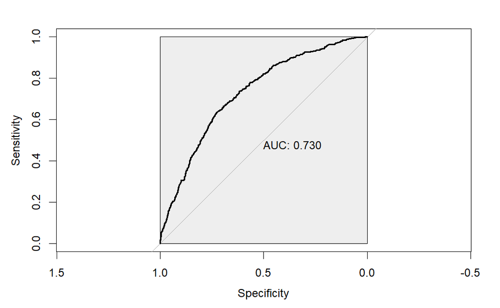

```r
plot(roc_model4, print.auc=TRUE, max.auc.polygon=TRUE)
```

`Epi` 패키지의 `ROC()`함수를 이용하는 방법은 아래의 코드와 같다.

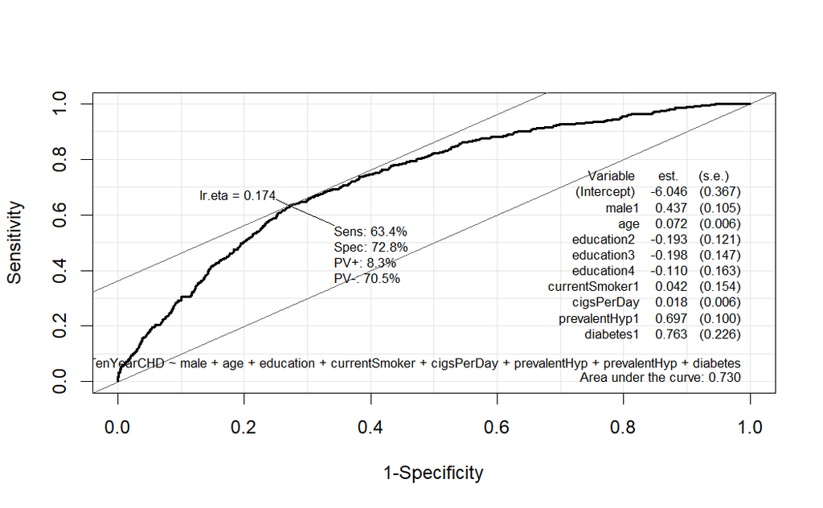

```r
#install.packages("Epi")
library(Epi)

ROC(form=formula(result_logistic4), data=df_complete, plot="ROC")
```

두 가지 분석결과의 ROC를 겹쳐 그릴 수 있다.

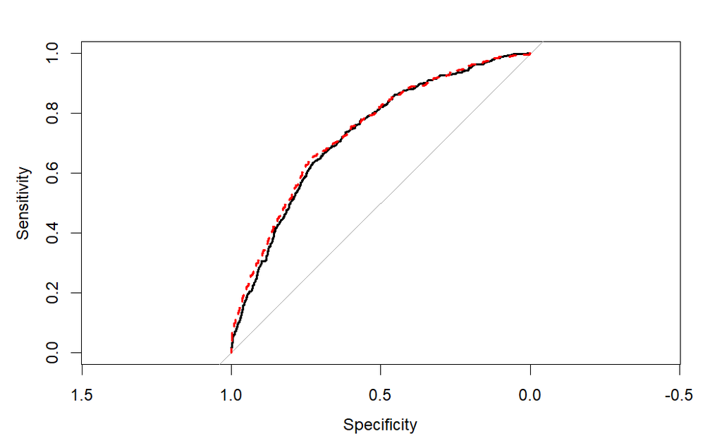

```r
plot(roc_model4)
plot(roc_model5, add=T, lty=2, col="red")
```

두 가지 모형의 AUC 값의 차이를 비교할 수 있다.

```r
roc.test(roc_model4, roc_model5)
```

```
    DeLong's test for two correlated ROC curves

data:  roc_model4 and roc_model5
Z = -2.5456, p-value = 0.01091
alternative hypothesis: true difference in AUC is not equal to 0
95 percent confidence interval:
 -0.017282771 -0.002246459
sample estimates:
AUC of roc1 AUC of roc2
  0.7298034   0.7395680
```

## 로지스틱 회귀 분석의 결과 정리

로지스틱 회귀 분석 결과에서 각 변수에 대한 Odds Ratio를 주요 결과로 제시한다. 분석 결과를 출력해 보면 아래와 같다.

```r
summary(result_logistic5)
```

```
Call:
glm(formula = TenYearCHD ~ male + age + education + currentSmoker +
    cigsPerDay + prevalentHyp + prevalentHyp + diabetes + totChol +
    sysBP + diaBP + BMI + heartRate + glucose, family = binomial(),
    data = df_complete)

Coefficients:
                Estimate Std. Error z value Pr(>|z|)
(Intercept)    -8.309998   0.708338 -11.732  < 2e-16 ***
male1           0.531910   0.109734   4.847 1.25e-06 ***
age             0.062493   0.006749   9.259  < 2e-16 ***
education2     -0.190778   0.123305  -1.547  0.12181
education3     -0.195641   0.150024  -1.304  0.19221
education4     -0.064118   0.164505  -0.390  0.69671
currentSmoker1  0.071564   0.156626   0.457  0.64773
cigsPerDay      0.017893   0.006232   2.871  0.00409 **
prevalentHyp1   0.248705   0.137433   1.810  0.07035 .
diabetes1       0.026853   0.315420   0.085  0.93215
totChol         0.002399   0.001128   2.127  0.03339 *
sysBP           0.015745   0.003780   4.165 3.11e-05 ***
diaBP          -0.004087   0.006434  -0.635  0.52533
BMI             0.005868   0.012765   0.460  0.64573
heartRate      -0.003316   0.004208  -0.788  0.43069
glucose         0.007221   0.002230   3.239  0.00120 **
---
Signif. codes:  0 ‘***’ 0.001 ‘**’ 0.01 ‘*’ 0.05 ‘.’ 0.1 ‘ ’ 1

(Dispersion parameter for binomial family taken to be 1)

    Null deviance: 3121.2  on 3657  degrees of freedom
Residual deviance: 2754.9  on 3642  degrees of freedom
AIC: 2786.9

Number of Fisher Scoring iterations: 5
```

Odds Ratio를 추출하기 위해서 추정된 계수를 지수변환하면 된다.

```r
exp(coef(result_logistic5)) # odds ratio
```

```
   (Intercept)          male1            age     education2     education3
  0.0002460446   1.7021803592   1.0644867833   0.8263160771   0.8223074304
    education4 currentSmoker1     cigsPerDay  prevalentHyp1      diabetes1
  0.9378938811   1.0741872806   1.0180541174   1.2823639755   1.0272168648
       totChol          sysBP          diaBP            BMI      heartRate
  1.0024018846   1.0158699132   0.9959217443   1.0058854476   0.9966897831
       glucose
  1.0072469632
```

```r
exp(confint(result_logistic5)) # odds ratio의 신뢰구간
```

```
프로파일링이 완료되길 기다리는 중입니다...
```

```
                      2.5 %       97.5 %
(Intercept)    6.064056e-05 0.0009752193
male1          1.373328e+00 2.1118706014
age            1.050563e+00 1.0787390679
education2     6.477322e-01 1.0506461089
education3     6.097815e-01 1.0987171376
education4     6.750692e-01 1.2876920761
currentSmoker1 7.884865e-01 1.4574021424
cigsPerDay     1.005650e+00 1.0305432094
prevalentHyp1  9.787361e-01 1.6777657292
diabetes1      5.438676e-01 1.8798641162
totChol        1.000177e+00 1.0046120748
sysBP          1.008377e+00 1.0234406650
diaBP          9.834613e-01 1.0085958364
BMI            9.808798e-01 1.0312457770
heartRate      9.884495e-01 1.0048946946
glucose        1.002911e+00 1.0117379298
```

```r
summary(result_logistic5)$coefficient[,4] # 유의확률 p-value
```

```
   (Intercept)          male1            age     education2     education3
  8.768759e-32   1.251624e-06   2.056644e-20   1.218149e-01   1.922116e-01
    education4 currentSmoker1     cigsPerDay  prevalentHyp1      diabetes1
  6.967095e-01   6.477332e-01   4.091999e-03   7.035115e-02   9.321546e-01
       totChol          sysBP          diaBP            BMI      heartRate
  3.339305e-02   3.107233e-05   5.253256e-01   6.457263e-01   4.306872e-01
       glucose
  1.201474e-03
```

패키지를 이용하면 편리하면 유용하다.

```r
library(moonBook)
library(ztable) # 뷰어창에 출력 시각화
```

```r
extractOR(result_logistic5)
```

|  | OR | lcl | ucl | p |
| --- | --- | --- | --- | --- |
| (Intercept) | 0.00 | 0.00 | 0.00 | 0.0000 |
| male1 | 1.70 | 1.37 | 2.11 | 0.0000 |
| age | 1.06 | 1.05 | 1.08 | 0.0000 |
| education2 | 0.83 | 0.65 | 1.05 | 0.1218 |
| education3 | 0.82 | 0.61 | 1.10 | 0.1922 |
| education4 | 0.94 | 0.68 | 1.29 | 0.6967 |
| currentSmoker1 | 1.07 | 0.79 | 1.46 | 0.6477 |
| cigsPerDay | 1.02 | 1.01 | 1.03 | 0.0041 |
| prevalentHyp1 | 1.28 | 0.98 | 1.68 | 0.0704 |
| diabetes1 | 1.03 | 0.55 | 1.91 | 0.9322 |

[output cut: 6 more lines]

### 결과의 시각화 표현

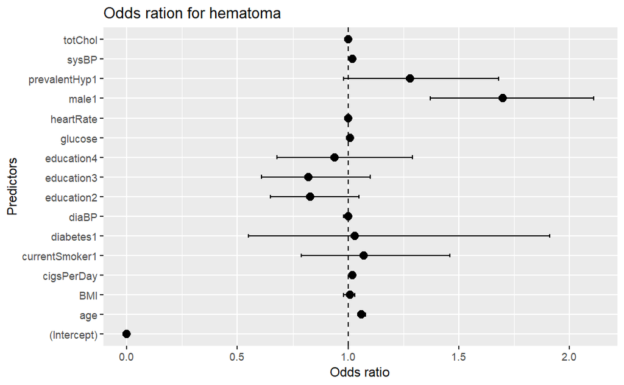

```r
library(ggplot2)
# 로지스틱 회귀 분석 결과에서 Odds ratio 추출
result_odds <- extractOR(result_logistic5)

# plot 그리기
ggplot(result_odds, aes(x = OR, y = rownames(result_odds))) +
  geom_vline(xintercept = 1, linetype = "dashed") +
  geom_errorbarh(aes(xmin = lcl, xmax = ucl), height = 0.2) +
  geom_point(size = 3) +
  ggtitle("Odds ration for hematoma") +
  xlab("Odds ratio") +
  ylab("Predictors")
```

`moonbook` 패키지에서 오즈비를 시각화해서 직관적으로 표현하기 위해 `ORplot()` 함수를 제공한다. `ORplot()`를 이용해서 세가지 모양의 그래프를 그릴 수 있으며(type=1,2,3), show.OR(default 값은 TRUE)와 show.CI(default 값은 FALSE)를 설정할 수 있다.

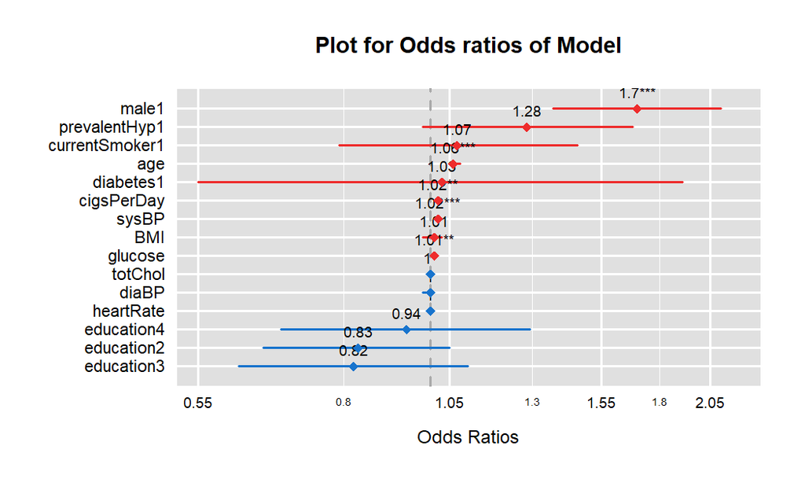

```r
ORplot(result_logistic5, type=1, main="Plot for Odds ratios of Model")
```

# 2. 생존분석(survival analysis)

생존 분석은 어떠한 현상이 발생하기까지에 걸리는 시간에 대해 분석하는 방법이다.

생존 분석의 주된 관심사는 생존함수(survival function) S(t)이며, 다음과 같이 정의한다.

$${\displaystyle S(t)=\Pr(T>t) = P(t)}$$
$t$는 시간변수, $T$는 사망에 이르는 시점이다.

의학연구에서는 Kaplan-Meier 생존 분석으로 이용해서 생존함수를 추정하고 사건의 발생률을 계산한다. 그리고 Cox proportional hazard model(Cox 비례위험모형)을 이용해서 사건의 발생에 미치는 위험 인자를 확인한다.

```r
#install.packages("survival")
#install.packages("survminer")
library(survival)
library(survminer)
```

## 분석 준비

```r
data(retinopathy, package="survival")
head(retinopathy)
```

|  | id | laser | eye | age | type | trt | futime | status | risk |
| --- | --- | --- | --- | --- | --- | --- | --- | --- | --- |
| 1 | 5 | argon | left | 28 | adult | 1 | 46.23 | 0 | 9 |
| 2 | 5 | argon | left | 28 | adult | 0 | 46.23 | 0 | 9 |
| 3 | 14 | argon | right | 12 | juvenile | 1 | 42.50 | 0 | 8 |
| 4 | 14 | argon | right | 12 | juvenile | 0 | 31.30 | 1 | 6 |
| 5 | 16 | xenon | right | 9 | juvenile | 1 | 42.27 | 0 | 11 |
| 6 | 16 | xenon | right | 9 | juvenile | 0 | 42.27 | 0 | 11 |

데이터셋은 `survival` 패키지에 내장되어 있는 데이터셋을 이용한다.

```r
str(retinopathy)
```

```
'data.frame':   394 obs. of  9 variables:
 $ id    : int  5 5 14 14 16 16 25 25 29 29 ...
 $ laser : Factor w/ 2 levels "xenon","argon": 2 2 2 2 1 1 2 2 1 1 ...
 $ eye   : Factor w/ 2 levels "right","left": 2 2 1 1 1 1 2 2 2 2 ...
 $ age   : int  28 28 12 12 9 9 9 9 13 13 ...
 $ type  : Factor w/ 2 levels "juvenile","adult": 2 2 1 1 1 1 1 1 1 1 ...
 $ trt   : int  1 0 1 0 1 0 1 0 1 0 ...
 $ futime: num  46.2 46.2 42.5 31.3 42.3 ...
 $ status: int  0 0 0 1 0 0 0 0 0 1 ...
 $ risk  : int  9 9 8 6 11 11 11 11 9 10 ...
```

자료의 변수 설명은 아래와 같다.

| 변수 종류 | 변수 명 | 설명 |
| --- | --- | --- |
| Explanatory variables | id | 대상자 번호 |
|  | laser | 검사에 사용된 레이저 유형 |
|  | eye | 치료 받은 눈의 위치: right left |
|  | age | 당뇨병 진단 당시 나이(세) |
|  | type | 당뇨병 종류: juvenile adult, (diagnosis before age 20) |
|  | trt | 0 = control eye, 1 = treated eye |
|  | futime | 시력 상실 또는 마지막 추적 관찰까지 기간 |
|  | status | 0 = censored, 1 = loss of vision in this eye |
|  | risk | risk score for the eye |

생존 분석을 위해서는 시간과 사건여부를 가지고 생존 객체를 만들어 주어야 한다. 생존 객체는 `Surv()`함수를 이용해서 만든다. `Surv(시간, 상태)`의 형태로 작성한다.

```r
Surv(retinopathy$futime, retinopathy$status == 1)[1:10] # 앞에서 10개를 출력
```

```
 [1] 46.23+ 46.23+ 42.50+ 31.30  42.27+ 42.27+ 20.60+ 20.60+ 38.77+  0.30
```